# Iris Species: Classification, Clustering, and PCA Lab

Comparing supervised and unsupervised approaches to flower morphology

Analytics Solutions Bootcamp

07 September 2026

```r
knitr::opts_chunk$set(
  echo = TRUE,
  message = FALSE,
  warning = FALSE,
  fig.width = 9,
  fig.height = 5
)

required_packages <- c(
  "tidyverse", "janitor", "rsample", "rpart", "rpart.plot",
  "yardstick", "cluster", "scales"
)

missing_packages <- required_packages[
  !required_packages %in% rownames(installed.packages())
]

if (length(missing_packages) > 0) {
  stop(
    "Install the missing packages first: ",
    paste(missing_packages, collapse = ", ")
  )
}

library(tidyverse)
library(janitor)
library(rsample)
library(rpart)
library(rpart.plot)
library(yardstick)
library(cluster)
library(scales)

set.seed(123)
```

# 1 Research scenario

A botanical field team studies three iris species using four measurements: sepal length, sepal width, petal length, and petal width. The team wants to know whether morphology can support species identification and whether natural groups emerge even when species labels are hidden.

The lab compares four analytical approaches:

1. Decision tree using the original measurements
2. Best K-means model using an optimized subset of measurements
3. Decision tree using selected principal components
4. K-means using selected principal components

## 1.1 Research questions

1. How do the four measurements vary among the three species?
2. Which combinations of measurements produce the most cohesive and separated natural clusters?
3. Does the optimal number of clusters agree with the three known species?
4. How closely do unlabeled clusters correspond to the actual species?
5. How many principal components are needed to retain at least 90% of the standardized measurement variance?
6. Does PCA preserve enough information for species identification and clustering?
7. Which of the four approaches best recovers the known species on held-out specimens?

> **Methodological note:** Species labels are used to train decision trees. K-means does not use species labels to form clusters. Feature combinations and cluster counts are selected using silhouette score on training measurements. Labels are consulted afterward only to evaluate and interpret the clusters.

# 2 1. Load and inspect the data

```r
data(iris)

iris_data <- iris |>
  clean_names() |>
  mutate(species = factor(species))

feature_names <- c(
  "sepal_length", "sepal_width", "petal_length", "petal_width"
)

glimpse(iris_data)
```

```
## Rows: 150
## Columns: 5
## $ sepal_length <dbl> 5.1, 4.9, 4.7, 4.6, 5.0, 5.4, 4.6, 5.0, 4.4, 4.9, 5.4, 4.…
## $ sepal_width  <dbl> 3.5, 3.0, 3.2, 3.1, 3.6, 3.9, 3.4, 3.4, 2.9, 3.1, 3.7, 3.…
## $ petal_length <dbl> 1.4, 1.4, 1.3, 1.5, 1.4, 1.7, 1.4, 1.5, 1.4, 1.5, 1.5, 1.…
## $ petal_width  <dbl> 0.2, 0.2, 0.2, 0.2, 0.2, 0.4, 0.3, 0.2, 0.2, 0.1, 0.2, 0.…
## $ species      <fct> setosa, setosa, setosa, setosa, setosa, setosa, setosa, s…
```

```r
tibble(
  specimens = nrow(iris_data),
  variables = ncol(iris_data),
  duplicate_rows = sum(duplicated(iris_data)),
  missing_values = sum(is.na(iris_data))
)
```

```
## # A tibble: 1 × 4
##   specimens variables duplicate_rows missing_values
##       <int>     <int>          <int>          <int>
## 1       150         5              1              0
```

```r
iris_data |>
  count(species) |>
  mutate(proportion = percent(n / sum(n), accuracy = 0.1))
```

```
##      species  n proportion
## 1     setosa 50      33.3%
## 2 versicolor 50      33.3%
## 3  virginica 50      33.3%
```

# 3 2. Explore flower morphology

```r
iris_data |>
  group_by(species) |>
  summarise(
    specimens = n(),
    across(
      all_of(feature_names),
      list(mean = mean, sd = sd),
      .names = "{.col}_{.fn}"
    ),
    .groups = "drop"
  )
```

```
## # A tibble: 3 × 10
##   species    specimens sepal_length_mean sepal_length_sd sepal_width_mean
##   <fct>          <int>             <dbl>           <dbl>            <dbl>
## 1 setosa            50              5.01           0.352             3.43
## 2 versicolor        50              5.94           0.516             2.77
## 3 virginica         50              6.59           0.636             2.97
## # ℹ 5 more variables: sepal_width_sd <dbl>, petal_length_mean <dbl>,
## #   petal_length_sd <dbl>, petal_width_mean <dbl>, petal_width_sd <dbl>
```

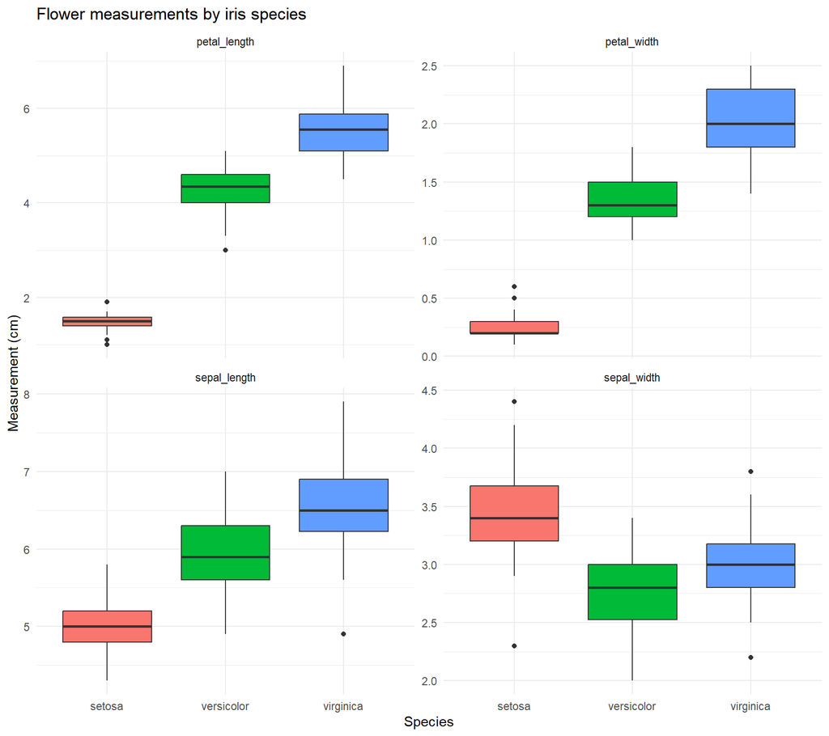

```r
iris_data |>
  pivot_longer(
    all_of(feature_names),
    names_to = "measurement",
    values_to = "centimeters"
  ) |>
  ggplot(aes(species, centimeters, fill = species)) +
  geom_boxplot(show.legend = FALSE) +
  facet_wrap(~ measurement, scales = "free_y", ncol = 2) +
  labs(
    title = "Flower measurements by iris species",
    x = "Species",
    y = "Measurement (cm)"
  ) +
  theme_minimal()
```

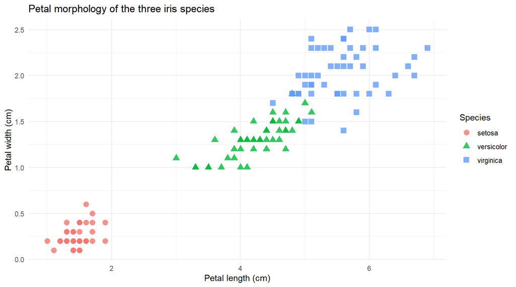

```r
ggplot(
  iris_data,
  aes(petal_length, petal_width, color = species, shape = species)
) +
  geom_point(size = 3, alpha = 0.8) +
  labs(
    title = "Petal morphology of the three iris species",
    x = "Petal length (cm)",
    y = "Petal width (cm)",
    color = "Species",
    shape = "Species"
  ) +
  theme_minimal()
```

# 4 3. Create training and test samples

All optimization occurs using the training data. The test data is reserved for the final four-model comparison.

```r
iris_split <- initial_split(
  iris_data,
  prop = 0.80,
  strata = species
)

train_data <- training(iris_split)
test_data <- testing(iris_split)

bind_rows(
  train_data |> count(species) |> mutate(dataset = "Training"),
  test_data |> count(species) |> mutate(dataset = "Test")
) |>
  group_by(dataset) |>
  mutate(proportion = percent(n / sum(n), accuracy = 0.1)) |>
  ungroup()
```

```
## # A tibble: 6 × 4
##   species        n dataset  proportion
##   <fct>      <int> <chr>    <chr>
## 1 setosa        40 Training 33.3%
## 2 versicolor    40 Training 33.3%
## 3 virginica     40 Training 33.3%
## 4 setosa        10 Test     33.3%
## 5 versicolor    10 Test     33.3%
## 6 virginica     10 Test     33.3%
```

# 5 4. Helper functions

The functions below keep preprocessing consistent and allow K-means clusters to be applied to held-out specimens.

```r
# Scale test data using means and standard deviations learned from training data.
standardize_pair <- function(train_matrix, test_matrix) {
  train_matrix <- as.matrix(train_matrix)
  test_matrix <- as.matrix(test_matrix)

  centers <- colMeans(train_matrix)
  scales <- apply(train_matrix, 2, sd)

  list(
    train = scale(train_matrix, center = centers, scale = scales),
    test = scale(test_matrix, center = centers, scale = scales),
    center = centers,
    scale = scales
  )
}

# Assign new rows to the nearest fitted K-means centroid.
nearest_cluster <- function(new_matrix, centers) {
  apply(new_matrix, 1, function(observation) {
    distances <- rowSums(
      (centers - matrix(
        observation,
        nrow = nrow(centers),
        ncol = ncol(centers),
        byrow = TRUE
      ))^2
    )
    which.min(distances)
  })
}

# Map each training cluster to its most frequent known species.
learn_cluster_labels <- function(clusters, truth) {
  tibble(cluster = clusters, species = truth) |>
    count(cluster, species) |>
    group_by(cluster) |>
    slice_max(n, n = 1, with_ties = FALSE) |>
    ungroup() |>
    select(cluster, species)
}

map_clusters_to_species <- function(clusters, label_map, species_levels) {
  lookup <- setNames(as.character(label_map$species), label_map$cluster)
  factor(lookup[as.character(clusters)], levels = species_levels)
}

# Adjusted Rand Index: label-invariant agreement between two partitions.
adjusted_rand_index <- function(truth, estimate) {
  tab <- table(truth, estimate)
  choose_2 <- function(x) x * (x - 1) / 2

  sum_cells <- sum(choose_2(tab))
  sum_rows <- sum(choose_2(rowSums(tab)))
  sum_cols <- sum(choose_2(colSums(tab)))
  total_pairs <- choose_2(sum(tab))
  expected <- sum_rows * sum_cols / total_pairs
  maximum <- (sum_rows + sum_cols) / 2

  (sum_cells - expected) / (maximum - expected)
}

macro_classification_metrics <- function(truth, estimate) {
  per_class <- map_dfr(levels(truth), function(current_class) {
    truth_binary <- factor(
      if_else(truth == current_class, current_class, "Other"),
      levels = c("Other", current_class)
    )
    estimate_binary <- factor(
      if_else(estimate == current_class, current_class, "Other"),
      levels = c("Other", current_class)
    )

    tibble(
      precision = precision_vec(
        truth_binary, estimate_binary, event_level = "second"
      ),
      recall = sens_vec(
        truth_binary, estimate_binary, event_level = "second"
      ),
      f1 = f_meas_vec(
        truth_binary, estimate_binary, event_level = "second"
      )
    )
  })

  tibble(
    accuracy = accuracy_vec(truth, estimate),
    macro_precision = mean(per_class$precision, na.rm = TRUE),
    macro_recall = mean(per_class$recall, na.rm = TRUE),
    macro_f1 = mean(per_class$f1, na.rm = TRUE),
    ari = adjusted_rand_index(truth, estimate)
  )
}
```

# 6 5. Zero-rule baseline

The zero-rule classifier predicts the most frequent training species for every test specimen. Since the classes are balanced, its expected accuracy is about one third.

```r
majority_species <- train_data |>
  count(species, sort = TRUE) |>
  slice(1) |>
  pull(species) |>
  as.character()

baseline_class <- factor(
  rep(majority_species, nrow(test_data)),
  levels = levels(iris_data$species)
)

accuracy_vec(test_data$species, baseline_class)
```

```
## [1] 0.3333333
```

# 7 6. Decision tree using original features

```r
feature_tree_full <- rpart(
  species ~ sepal_length + sepal_width + petal_length + petal_width,
  data = train_data,
  method = "class",
  parms = list(split = "information"),
  control = rpart.control(cp = 0.001, minsplit = 10, xval = 10)
)

feature_tree_cp <- feature_tree_full$cptable[
  which.min(feature_tree_full$cptable[, "xerror"]),
  "CP"
]

feature_tree <- prune(feature_tree_full, cp = feature_tree_cp)

feature_tree_prediction <- predict(
  feature_tree,
  newdata = test_data,
  type = "class"
)
```

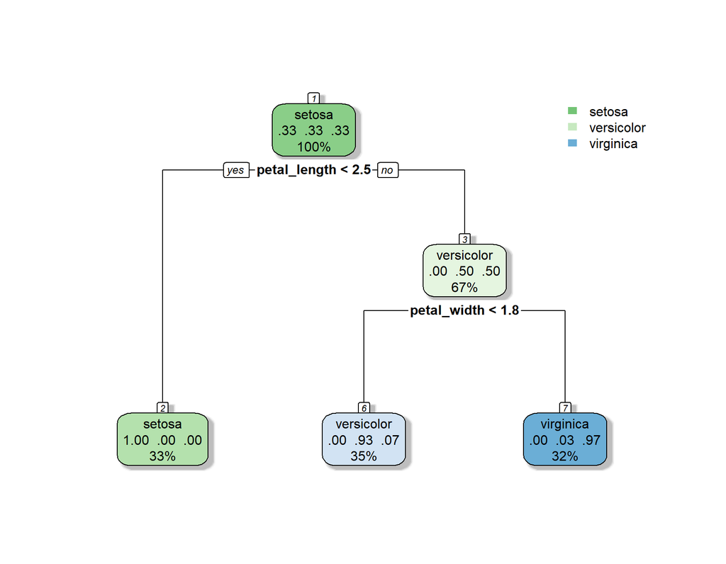

```r
rpart.plot(
  feature_tree,
  type = 2,
  extra = 104,
  fallen.leaves = TRUE,
  box.palette = "GnBu",
  shadow.col = "gray",
  nn = TRUE
)
```

```r
enframe(
  feature_tree$variable.importance,
  name = "measurement",
  value = "importance"
) |>
  mutate(relative_importance = importance / sum(importance)) |>
  arrange(desc(relative_importance))
```

```
## # A tibble: 4 × 3
##   measurement  importance relative_importance
##   <chr>             <dbl>               <dbl>
## 1 petal_width       116.                0.334
## 2 petal_length      110.                0.316
## 3 sepal_length       78.0               0.224
## 4 sepal_width        44.0               0.126
```

# 8 7. Optimize K-means feature combinations

K-means is sensitive to scale, so every candidate feature set is standardized using training statistics. We test all nonempty combinations of the four features and candidate values of $k$ from 2 to 6.

The selection criterion is **average silhouette width**:

- Values near 1 indicate compact, well-separated clusters.
- Values near 0 indicate overlapping clusters.
- Negative values suggest possible misassignment.

Species labels are not used in this search.

```r
feature_combinations <- map(
  seq_along(feature_names),
  ~ combn(feature_names, .x, simplify = FALSE)
) |>
  flatten()

evaluate_kmeans_candidate <- function(features, k) {
  candidate_matrix <- train_data |>
    select(all_of(features)) |>
    scale()

  set.seed(123)
  fitted <- kmeans(candidate_matrix, centers = k, nstart = 50)
  silhouette_values <- silhouette(
    fitted$cluster,
    dist(candidate_matrix)
  )

  tibble(
    features = paste(features, collapse = " + "),
    feature_count = length(features),
    k = k,
    silhouette = mean(silhouette_values[, "sil_width"])
  )
}

kmeans_search <- map_dfr(feature_combinations, function(features) {
  map_dfr(2:6, ~ evaluate_kmeans_candidate(features, .x))
})

kmeans_search |>
  arrange(desc(silhouette)) |>
  slice_head(n = 15)
```

[output not shown]

```r
best_feature_candidate <- kmeans_search |>
  slice_max(silhouette, n = 1, with_ties = FALSE)

best_feature_names <- str_split(
  best_feature_candidate$features,
  fixed(" + ")
)[[1]]

best_feature_k <- best_feature_candidate$k[[1]]

best_feature_candidate
```

```
## # A tibble: 1 × 4
##   features     feature_count     k silhouette
##   <chr>                <int> <int>      <dbl>
## 1 petal_length             1     2      0.774
```

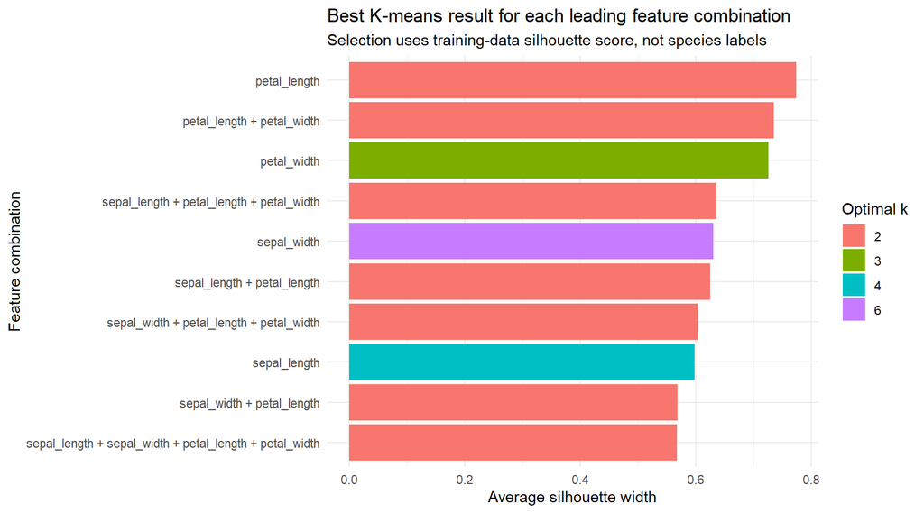

```r
kmeans_search |>
  group_by(features) |>
  slice_max(silhouette, n = 1, with_ties = FALSE) |>
  ungroup() |>
  slice_max(silhouette, n = 10) |>
  mutate(features = reorder(features, silhouette)) |>
  ggplot(aes(features, silhouette, fill = factor(k))) +
  geom_col() +
  coord_flip() +
  labs(
    title = "Best K-means result for each leading feature combination",
    subtitle = "Selection uses training-data silhouette score, not species labels",
    x = "Feature combination",
    y = "Average silhouette width",
    fill = "Optimal k"
  ) +
  theme_minimal()
```

## 8.1 Fit and apply the best feature-based K-means model

```r
feature_scaled <- standardize_pair(
  train_data |> select(all_of(best_feature_names)),
  test_data |> select(all_of(best_feature_names))
)

set.seed(123)
best_feature_kmeans <- kmeans(
  feature_scaled$train,
  centers = best_feature_k,
  nstart = 100
)

feature_cluster_map <- learn_cluster_labels(
  best_feature_kmeans$cluster,
  train_data$species
)

feature_test_clusters <- nearest_cluster(
  feature_scaled$test,
  best_feature_kmeans$centers
)

feature_kmeans_prediction <- map_clusters_to_species(
  feature_test_clusters,
  feature_cluster_map,
  levels(iris_data$species)
)

feature_cluster_map
```

```
## # A tibble: 2 × 2
##   cluster species
##     <int> <fct>
## 1       1 virginica
## 2       2 setosa
```

## 8.2 Compare training clusters with actual classes

```r
table(
  Actual_species = train_data$species,
  Kmeans_cluster = best_feature_kmeans$cluster
)
```

```
##               Kmeans_cluster
## Actual_species  1  2
##     setosa      0 40
##     versicolor 39  1
##     virginica  40  0
```

```r
adjusted_rand_index(
  train_data$species,
  best_feature_kmeans$cluster
)
```

```
## [1] 0.5551082
```

The Adjusted Rand Index (ARI) compares two partitions without requiring cluster numbers to match species names. A value near 1 indicates strong agreement; a value near 0 indicates agreement similar to chance.

# 9 8. Principal component analysis

PCA transforms correlated measurements into uncorrelated components. It is fit on standardized training measurements only. We retain the smallest number of components whose cumulative explained variance reaches 90%.

```r
pca_model <- prcomp(
  train_data |> select(all_of(feature_names)),
  center = TRUE,
  scale. = TRUE
)

pca_variance <- tibble(
  component = seq_along(pca_model$sdev),
  principal_component = paste0("PC", component),
  variance_explained = pca_model$sdev^2 / sum(pca_model$sdev^2)
) |>
  mutate(cumulative_variance = cumsum(variance_explained))

pca_variance
```

```
## # A tibble: 4 × 4
##   component principal_component variance_explained cumulative_variance
##       <int> <chr>                            <dbl>               <dbl>
## 1         1 PC1                            0.717                 0.717
## 2         2 PC2                            0.239                 0.956
## 3         3 PC3                            0.0388                0.995
## 4         4 PC4                            0.00507               1
```

```r
variance_threshold <- 0.90

optimal_pc_count <- which(
  pca_variance$cumulative_variance >= variance_threshold
)[1]

optimal_pc_names <- paste0("PC", seq_len(optimal_pc_count))

tibble(
  variance_threshold = percent(variance_threshold),
  retained_components = optimal_pc_count,
  retained_variance = percent(
    pca_variance$cumulative_variance[optimal_pc_count],
    accuracy = 0.1
  )
)
```

```
## # A tibble: 1 × 3
##   variance_threshold retained_components retained_variance
##   <chr>                            <int> <chr>
## 1 90%                                  2 95.6%
```

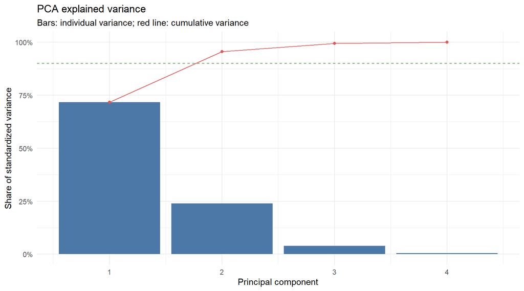

```r
ggplot(pca_variance, aes(component, variance_explained)) +
  geom_col(fill = "#4C78A8") +
  geom_line(aes(y = cumulative_variance), color = "#E45756") +
  geom_point(aes(y = cumulative_variance), color = "#E45756") +
  geom_hline(
    yintercept = variance_threshold,
    linetype = "dashed",
    color = "#54A24B"
  ) +
  scale_x_continuous(breaks = pca_variance$component) +
  scale_y_continuous(labels = percent, limits = c(0, 1)) +
  labs(
    title = "PCA explained variance",
    subtitle = "Bars: individual variance; red line: cumulative variance",
    x = "Principal component",
    y = "Share of standardized variance"
  ) +
  theme_minimal()
```

## 9.1 Interpret component loadings

```r
as_tibble(
  pca_model$rotation[, optimal_pc_names, drop = FALSE],
  rownames = "measurement"
)
```

```
## # A tibble: 4 × 3
##   measurement     PC1     PC2
##   <chr>         <dbl>   <dbl>
## 1 sepal_length  0.532 -0.329
## 2 sepal_width  -0.222 -0.943
## 3 petal_length  0.586 -0.0144
## 4 petal_width   0.570 -0.0464
```

Large positive or negative loadings indicate measurements that contribute strongly to a component. The sign indicates direction, not importance by itself.

## 9.2 Transform training and test data

```r
train_pc_scores <- predict(
  pca_model,
  newdata = train_data |> select(all_of(feature_names))
) |>
  as_tibble()

test_pc_scores <- predict(
  pca_model,
  newdata = test_data |> select(all_of(feature_names))
) |>
  as_tibble()

train_pc_data <- train_pc_scores |>
  select(all_of(optimal_pc_names)) |>
  mutate(species = train_data$species)

test_pc_data <- test_pc_scores |>
  select(all_of(optimal_pc_names)) |>
  mutate(species = test_data$species)
```

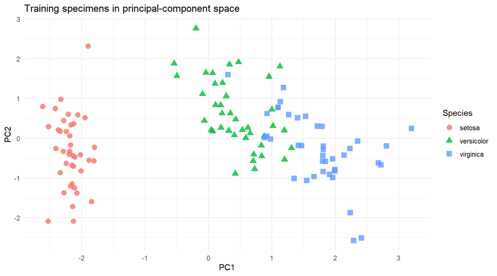

```r
if (optimal_pc_count >= 2) {
  ggplot(
    train_pc_data,
    aes(PC1, PC2, color = species, shape = species)
  ) +
    geom_point(size = 3, alpha = 0.8) +
    labs(
      title = "Training specimens in principal-component space",
      color = "Species",
      shape = "Species"
    ) +
    theme_minimal()
}
```

# 10 9. Decision tree using optimal principal components

```r
pca_tree_full <- rpart(
  species ~ .,
  data = train_pc_data,
  method = "class",
  parms = list(split = "information"),
  control = rpart.control(cp = 0.001, minsplit = 10, xval = 10)
)

pca_tree_cp <- pca_tree_full$cptable[
  which.min(pca_tree_full$cptable[, "xerror"]),
  "CP"
]

pca_tree <- prune(pca_tree_full, cp = pca_tree_cp)

pca_tree_prediction <- predict(
  pca_tree,
  newdata = test_pc_data,
  type = "class"
)
```

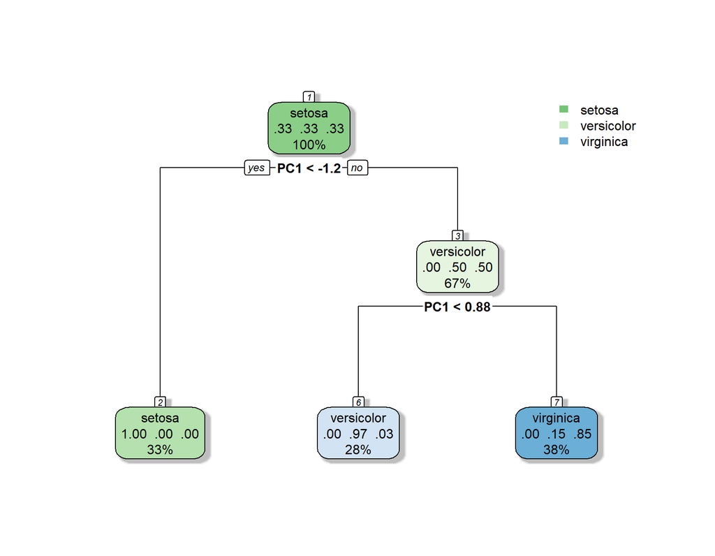

```r
rpart.plot(
  pca_tree,
  type = 2,
  extra = 104,
  fallen.leaves = TRUE,
  box.palette = "GnBu",
  shadow.col = "gray",
  nn = TRUE
)
```

# 11 10. K-means using optimal principal components

The retained PCs already come from standardized inputs and are mutually uncorrelated. We choose $k$ using training-data silhouette score.

```r
pca_train_matrix <- train_pc_scores |>
  select(all_of(optimal_pc_names)) |>
  as.matrix()

pca_test_matrix <- test_pc_scores |>
  select(all_of(optimal_pc_names)) |>
  as.matrix()

pca_k_search <- map_dfr(2:6, function(k) {
  set.seed(123)
  fitted <- kmeans(pca_train_matrix, centers = k, nstart = 50)
  silhouette_values <- silhouette(
    fitted$cluster,
    dist(pca_train_matrix)
  )

  tibble(
    k = k,
    silhouette = mean(silhouette_values[, "sil_width"])
  )
})

pca_k_search
```

```
## # A tibble: 5 × 2
##       k silhouette
##   <int>      <dbl>
## 1     2      0.601
## 2     3      0.517
## 3     4      0.501
## 4     5      0.452
## 5     6      0.461
```

```r
best_pca_k <- pca_k_search |>
  slice_max(silhouette, n = 1, with_ties = FALSE) |>
  pull(k)

set.seed(123)
pca_kmeans <- kmeans(
  pca_train_matrix,
  centers = best_pca_k,
  nstart = 100
)

pca_cluster_map <- learn_cluster_labels(
  pca_kmeans$cluster,
  train_data$species
)

pca_test_clusters <- nearest_cluster(
  pca_test_matrix,
  pca_kmeans$centers
)

pca_kmeans_prediction <- map_clusters_to_species(
  pca_test_clusters,
  pca_cluster_map,
  levels(iris_data$species)
)

tibble(
  retained_components = optimal_pc_count,
  optimal_k = best_pca_k,
  silhouette = max(pca_k_search$silhouette)
)
```

```
## # A tibble: 1 × 3
##   retained_components optimal_k silhouette
##                 <int>     <int>      <dbl>
## 1                   2         2      0.601
```

```r
table(
  Actual_species = train_data$species,
  PCA_Kmeans_cluster = pca_kmeans$cluster
)
```

```
##               PCA_Kmeans_cluster
## Actual_species  1  2
##     setosa     40  0
##     versicolor  0 40
##     virginica   0 40
```

```r
adjusted_rand_index(
  train_data$species,
  pca_kmeans$cluster
)
```

```
## [1] 0.5672727
```

# 12 11. Final comparison of four approaches

For a fair final comparison, all four approaches are evaluated on the same untouched test specimens.

For K-means, training clusters are mapped to their majority species and test specimens are assigned to the nearest centroid. Accuracy, precision, recall, and F1 therefore measure recovery of the known species after mapping. ARI is also reported because it evaluates partition agreement without depending on label names.

```r
comparison_results <- bind_rows(
  macro_classification_metrics(
    test_data$species,
    feature_tree_prediction
  ) |>
    mutate(model = "Decision tree: original features"),
  macro_classification_metrics(
    test_data$species,
    feature_kmeans_prediction
  ) |>
    mutate(model = "Best K-means: selected features"),
  macro_classification_metrics(
    test_data$species,
    pca_tree_prediction
  ) |>
    mutate(model = "Decision tree: selected PCs"),
  macro_classification_metrics(
    test_data$species,
    pca_kmeans_prediction
  ) |>
    mutate(model = "K-means: selected PCs")
) |>
  select(model, everything()) |>
  arrange(desc(accuracy), desc(macro_f1))

comparison_results |>
  mutate(across(where(is.numeric), ~ round(.x, 3)))
```

```
## # A tibble: 4 × 6
##   model                     accuracy macro_precision macro_recall macro_f1   ari
##   <chr>                        <dbl>           <dbl>        <dbl>    <dbl> <dbl>
## 1 Decision tree: original …    0.933           0.944        0.933    0.933 0.808
## 2 Decision tree: selected …    0.9             0.923        0.9      0.898 0.731
## 3 Best K-means: selected f…    0.667           0.75         0.667    0.833 0.554
## 4 K-means: selected PCs        0.667           0.75         0.667    0.833 0.554
```

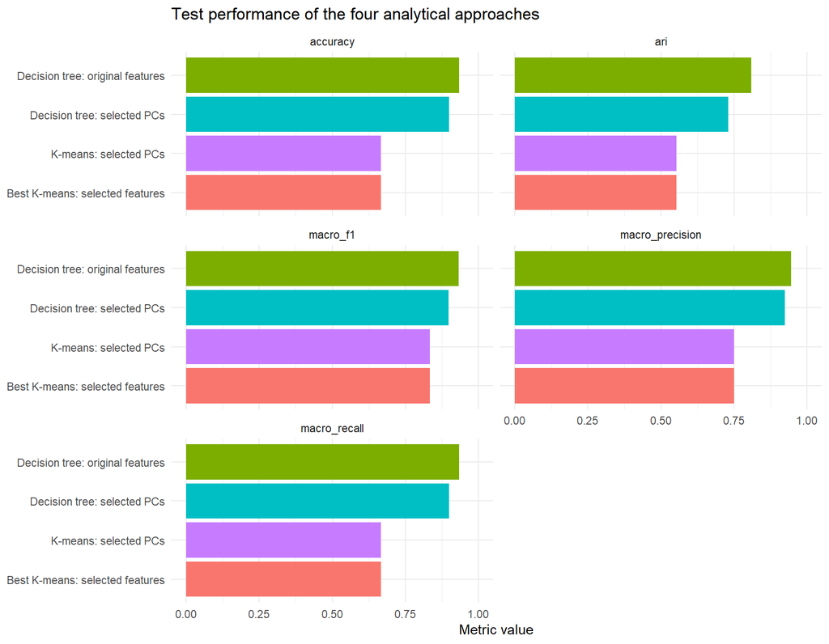

```r
comparison_results |>
  pivot_longer(
    c(accuracy, macro_precision, macro_recall, macro_f1, ari),
    names_to = "metric",
    values_to = "estimate"
  ) |>
  ggplot(aes(reorder(model, estimate), estimate, fill = model)) +
  geom_col(show.legend = FALSE) +
  coord_flip() +
  facet_wrap(~ metric, ncol = 2) +
  scale_y_continuous(limits = c(0, 1)) +
  labs(
    title = "Test performance of the four analytical approaches",
    x = NULL,
    y = "Metric value"
  ) +
  theme_minimal()
```

## 12.1 Confusion matrices

```r
prediction_sets <- list(
  "Decision tree: original features" = feature_tree_prediction,
  "Best K-means: selected features" = feature_kmeans_prediction,
  "Decision tree: selected PCs" = pca_tree_prediction,
  "K-means: selected PCs" = pca_kmeans_prediction
)

walk(names(prediction_sets), function(model_name) {
  cat("\n\n### ", model_name, "\n\n", sep = "")
  print(
    conf_mat(
      tibble(
        truth = test_data$species,
        estimate = prediction_sets[[model_name]]
      ),
      truth,
      estimate
    )
  )
})
```

```
##
##
## ### Decision tree: original features
##
##             Truth
## Prediction   setosa versicolor virginica
##   setosa         10          0         0
##   versicolor      0         10         2
##   virginica       0          0         8
##
##
## ### Best K-means: selected features
##
##             Truth
## Prediction   setosa versicolor virginica
##   setosa         10          0         0
##   versicolor      0          0         0
##   virginica       0         10        10
##
##
## ### Decision tree: selected PCs
##
##             Truth
## Prediction   setosa versicolor virginica
##   setosa         10          0         0
##   versicolor      0          7         0
##   virginica       0          3        10
##
##
## ### K-means: selected PCs
##
##             Truth
## Prediction   setosa versicolor virginica
##   setosa         10          0         0
##   versicolor      0         10        10
##   virginica       0          0         0
```

## 12.2 Model-selection summary

```r
tibble(
  item = c(
    "Best raw-feature combination",
    "Best raw-feature K-means k",
    "Best raw-feature silhouette",
    "PCA variance threshold",
    "Retained principal components",
    "Best PCA K-means k",
    "Best PCA K-means silhouette"
  ),
  result = c(
    best_feature_candidate$features,
    as.character(best_feature_k),
    round(best_feature_candidate$silhouette, 3),
    percent(variance_threshold),
    paste(optimal_pc_names, collapse = " + "),
    as.character(best_pca_k),
    round(max(pca_k_search$silhouette), 3)
  )
)
```

```
## # A tibble: 7 × 2
##   item                          result
##   <chr>                         <chr>
## 1 Best raw-feature combination  petal_length
## 2 Best raw-feature K-means k    2
## 3 Best raw-feature silhouette   0.774
## 4 PCA variance threshold        90%
## 5 Retained principal components PC1 + PC2
## 6 Best PCA K-means k            2
## 7 Best PCA K-means silhouette   0.601
```

# 13 12. Interpret the research findings

Use the outputs to answer:

1. Which original measurements most clearly separate the species?
2. Which feature combination and value of $k$ maximize silhouette score?
3. Does the internally optimal $k$ match the three known species? If not, what does that reveal about natural morphological groupings?
4. Which known species is recovered most cleanly by K-means?
5. How much standardized variance is retained by the selected PCs?
6. Which original measurements contribute most strongly to the retained PCs?
7. Does using PCA improve or reduce decision-tree performance?
8. Does using PCA improve cluster cohesion or agreement with known species?
9. Which of the four methods has the best test accuracy and macro F1 score?
10. Do silhouette and ARI select the same preferred clustering solution? Explain why an internally cohesive clustering can still disagree with known labels.

# 14 13. Limitations and responsible interpretation

- K-means finds geometric groups; it does not discover biological truth.
- Selecting the feature set by silhouette favors cluster geometry, not recovery of species labels.
- Mapping clusters to species is performed only to interpret and evaluate the clusters. It does not turn K-means into a supervised training algorithm.
- The Iris dataset is small, balanced, and historically used for teaching.
- A random split does not test generalization to another location, season, or measurement team.
- PCA maximizes retained variance, not classification accuracy or biological importance.
- Decision-tree splits and PCA loadings describe patterns, not biological causes.
- A single split can produce unstable rankings; repeated cross-validation or repeated train/test experiments should be used for stronger conclusions.

# 15 14. Optional learner exercises

1. Force $k=3$ for every K-means candidate and compare the outcome with the silhouette-selected models.
2. Select the best feature combination using ARI instead of silhouette. Explain why this changes the problem from purely unsupervised selection.
3. Change the PCA threshold to 80% and 95%. How do the retained PCs and model rankings change?
4. Repeat the entire workflow across several random seeds and summarize the variability of each metric.
5. Compare the one-standard-error pruning rule with minimum cross-validation error for both decision trees.
6. Investigate misclassified specimens and propose additional measurements that could distinguish `versicolor` from `virginica`.